# ST Edge AI Core - Command-line Interface

## Runtime memory size

“Runtime” identifies all involved *kernel* objects (software components) which are requested to execute the deployed c-model on a given device (also called runtime AI-stack). To compute these information, the `'--target'` option is used to know the targeted device and an embedded gcc-based compiler application should be available in the `PATH`.

The first part indicates the final contribution by module (generated c-file or library) and by type of memory segment. `'RT total'` line sum-ups the different contributors. `'lib (toolchain)'` indicates the contribution of the used toolchain objects (including typically the low-level floating point operations from the libm/libgcc libraries). The extra lines `weights/activations/io` recalls the requested size for respectively the weights, the activations buffer and the payload for the input/output tensors (refer to *“memory-related metrics”* section from *“Evaluation report and metrics”* article).

| segment | description |
| --- | --- |
| text | size in bytes for the code |
| rodata | size in bytes for the const data (usually stored in nonvolatile memory device, FLASH type, except for ISPU) |
| data | size in bytes for the initialized data (stored in volatile memory device like embedded RAM, initial values is stored in FLASH, except for ISPU) |
| bss | size in bytes for the zero-initialized data (stored in RAM) |

```
$ stedgeai analyze -m <model_path> --target stm32h7 --c-api legacy
...
 Requested memory size by section - "stm32h7" target
 ----------------------------- -------- -------- ------- --------
 module                            text   rodata    data      bss
 ----------------------------- -------- -------- ------- --------
 NetworkRuntime910_CM7_GCC.a     19,100        0       0        0
 network.o                          482      213   1,520      116
 network_data.o                      48       16      88        0
 lib (toolchain)*                   104        0       0        0
 ----------------------------- -------- -------- ------- --------
 RT total**                      19,734      229   1,608      116
 ----------------------------- -------- -------- ------- --------
 weights                              0   16,688       0        0
 activations                          0        0       0   12,004
 io                                   0        0       0    1,964
 ----------------------------- -------- -------- ------- --------
 TOTAL                           19,734   16,917   1,608   14,084
 ----------------------------- -------- -------- ------- --------
 *  toolchain objects (libm/libgcc*)
 ** RT AI runtime objects (kernels+infrastructure)
```

| module | description |
| --- | --- |
| NetworkRuntime910_CM7_GCC.a | kernel objects implementing the requested operators |
| network.o | specialized code/data to manage the c-model |
| network_data.o | specialized code/data to manage the weight/activation buffers |

> Note that the `'<network>_params_data.o'` file does not appear in the table, because it contains only the values of the weights (c-array form) which is represented by the `'*weights*`’ extra line.

The last part summarizes the whole requested memory size per type of memory. It also illustrates the breakdown between the RT objects and the main dimensioning memory-related metrics of the deployed c-model (that is, ROM/RAM metrics).

```
  Summary - "stm32h7" target
  ---------------------------------------------------
               FLASH (ro)      %*   RAM (rw)       %
  ---------------------------------------------------
  RT total         21,571   56.4%      1,724   11.0%
  ---------------------------------------------------
  TOTAL            38,259             15,692
  ---------------------------------------------------
  *  rt/total
```

### ISPU example

The following log illustrates an example for the `'ispu'` target. In the final summary, as the firmware is loaded in the internal RAM through a serial interface by a host processor, the requested size to store the initialized value of the `.data` section is not considered.

```
$ stedgeai analyze -m <model_path> --target ispu --c-api stai
...
 Requested memory size by section - "ispu" target
 ------------------- -------- -------- ------ --------
 module                  text   rodata   data      bss
 ------------------- -------- -------- ------ --------
 network_runtime.a     10,970        0      4        0
 network.o              1,968       80      0        0
 lib (toolchain)*       1,844      428      0        0
 ------------------- -------- -------- ------ --------
 RT total**            14,782      508      4        0
 ------------------- -------- -------- ------ --------
 weights                    0   16,688      0        0
 activations                0        0      0   12,004
 states                     0        0      0        0
 io                         0        0      0    1,964
 ------------------- -------- -------- ------ --------
 TOTAL                 14,782   17,196      4   13,968
 ------------------- -------- -------- ------ --------
 *  toolchain objects (libm/libgcc*)
 ** RT AI runtime objects (kernels+infrastructure)

  Summary - "ispu" target
  ----------------------------------------------------------
               Code RAM (ro)      %*   Data RAM (rw)      %
  ----------------------------------------------------------
  RT total            15,290   47.8%               4   0.0%
  ----------------------------------------------------------
  TOTAL               31,978                  13,972
  ----------------------------------------------------------
  *  rt/total
```

# Validate command

- stm32xx (including the stm32n6 series w/o NPU)
- sr5[xx]
- sr6p[xx]
- sr6g[xx]
- ispu
- mlc (see specific article)

## Description

The `'validate'` command allows validating the generated/deployed model. Two modes (`--mode` option) are considered: `host` and `target`. The detailed descriptions of the used metrics are described in the *“Evaluation report and metrics”* article.

### Native host runtime environment for model evaluation

The native runtime environment executes the original model on the host machine. This runtime relies on Python packages associated with the framework used to evaluate the model, such as the TFLite interpreter for the TFLite file, ONNX runtime for the ONNX-based model, and the Keras package with TensorFlow backend for Keras files. These runtimes are embedded into the ST Edge AI CLI executable without modification. Use the `'stedgeai --tools-version'` command to check the versions of the associated packages. The purpose of these environments is to generate references for *comparison* with the **predictions produced by the deployed model** in terms of accuracy. Execution time is not considered. Therefore, all optimizations aimed at improving inference time for the quantized models are disabled by default to utilize the reference kernels, avoiding side effects related to the CPU-specific optimizations. For the ONNX model, the ONNX runtime session is configured with the `onnxruntime.GraphOptimizationLevel.ORT_DISABLE_ALL` option and for the TFlite models, the experimental TFLite interpreter option (`tf.lite.experimental.OpResolverType.BUILTIN_REF`) to use the reference kernels should be enabled with the additional options: `--validate.experimentale kref`.

```bash
$ stedgeai validate -m <tflite_model>.tflite --target stm32h7 --validate.experimental kref
```

### Validation on host

Option: `'--mode host'` (Default)

The specialized NN generated c-files are compiled on the host and linked with a specific network-runtime library implementing the reference C-kernels closed to the target implementation.

[figure not shown]

### Validation on target

Option: `'--mode target -d <desc>'`

This mode allows validation of the deployed model on the associated board. Before executing the `'validate'` command, flash the board with a specific validation firmware that includes a dedicated COM stack and the deployed C-model. For each target, the method to deploy the model on the associated development board can differ.

[figure not shown]

- How-to create an STM32 validation firmware using [STM32Cube AI Studio (https://wiki.st.com/stm32mcu/wiki/AI)](https://wiki.st.com/stm32mcu/wiki/AI:STM32Cube_AI_Studio_documentation)
- How to evaluate a model deployed on the Neural ART accelerator™ on STM32N6 board
- How-to create an ISPU validation firmware
- How-to create a STELLAR validation firmware

When the board is flashed and started, the same validation process applies. Only the execution of the deployed C-model is delegated to the target.

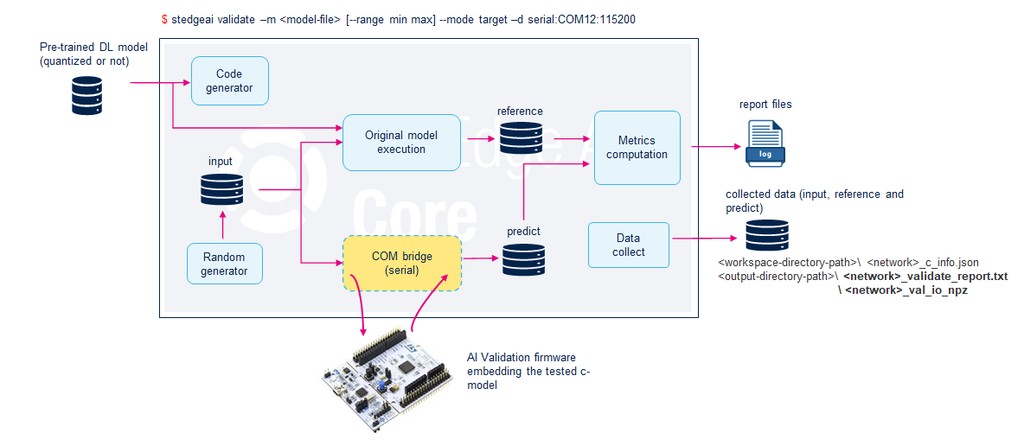

## Examples

- Minimal command to validate a model with self-generated random input data, *“Validation on desktop”*, default mode: --mode host.

  ```bash
  stedgeai validate -m <model_file_path> --target stm32
  ```

- Minimal command to validate a model on STM32H7-based board. Note that a complete profiling report including execution time by layer is generated by default.

  ```bash
  stedgeai validate -m <model_file_path> --mode target --target stm32h7 --desc serial
  ```

- Validation of a 32b float model with compression factor.

  ```bash
  stedgeai validate -m <model_f32p_file_path> -c medium --target stm32
  ```

- Validate a model with a custom dataset (input samples)

  ```bash
  stedgeai validate -m <model_file_path> -vi test_data.csv --target stm32
  ```

## Specific options

### `--mode`

Indicates the mode of validation. This option is optional.

| mode | description |
| --- | --- |
| `'host'` | **Default** value - Performs validation on the host. |
| `'target'` | Perform a validation on target. |
| `'host-io-only'` | Alias equivalent to ‘–mode host –io-only’ - deprecated - default behavior |
| `'target-io-only'` | Alias equivalent to ‘–mode target –io-only’ |

### `--val-json`

Specifies the generated `<network>_c_info.json` file to use during model validation. This option is valid only when running the validate command in target mode. It improves execution time by skipping preliminary passes, such as importing or compiling the model file. All required information is extracted directly from the provided JSON file. After validation, the file is updated with computed metrics, including measured inference time information. This option is optional.

Note

Since the release 3.0, if this option is not specified, the computed metrics and measured inference time information are stored in an extra file: `"<network>_c_info_valid.json"`.

### `-vi/--valinput`

Indicates the custom test dataset to use. If not defined, an internal self-generated random dataset is used (refer to *“Input validation files”* section). This option is optional.

### `-vo/--valoutput`

Indicates the expected custom output values. If the data are already provided in a simple file (`'*.npz'`) through the `'-vi'` option this argument is skipped. This option is optional.

### `-b/--batches`

Indicate how many random data samples are generated (default: 10) or how many custom test data are used (default: all). This option is optional.

### `-d/--desc`

Describe the protocol and associated parameters required to communicate with the deployed C-model. The syntax is `'<driver>[:parameters]'`. This option is *mandatory* if the --mode target option is specified. A typical use case is to specify the COM port used to communicate with a board (see “Serial COM port configuration” section).

### `--full`

- supported target: `stm32xx`, `sr5[xx]`, `sr6p[xx]`, `sr6g[xx]`
- unsupported target: `ispu`, `stm32n6` with NPU, `mlc`

Apply an extended validation process to report the *L2r* error layer-by-layer for the *floating-point Keras model*. Otherwise, the L2r is evaluated only on the last or output layers. This option is optional.

### `--io-only`

Force the execution of the deployed model without instrumentation to retrieve the intermediate data. This option is optional.

### `--classifier`

Consider the provided model as a classifier. This implies that the computation of the CM and ACC metrics is performed. Otherwise, an autodetection mechanism is used to determine if the model is a classifier. This option is optional.

### `--no-check`

When combined with the `'target'` mode, reduce the full preliminary checklist for debugging purposes to ensure that the flashed target C-model has been generated with the same tools and options. Only the C-name and network I/O shape and format are checked. This option is optional.

### `--no-exec-model`

Do not execute the original model on the host with a deep learning framework runtime. Only the generated C-model is executed (see the*“Evaluation report and metrics”* article). This option is optional.

### `--range`

Indicate the minimum and maximum values (in float) for the generated random data. The default is `'[0.0, 1.0['`. To generate random and uniform data between -1.0 and 1.0, use the following parameters: `'--range -1 1'` (refer to the *“Random data generation”* section). This option is optional.

### `--seed`

Define the seed used to initialize the pseudorandom number generator for random data generation. Otherwise, a fixed seed is used. This option is optional.

### `--save-csv`

Save all data in the respective `'*.csv'` files. By default, for performance reasons, only a limited part is saved. This option is optional.

For the ISPU target, an additional option is defined to specify the file needed to load the ISPU program (see the *“Validate command extension”* section of the ISPU-specific documentation).

## Serial COM port configuration

Use the `'-d/--desc'` option to configure the serial COM driver for board access. By default, the autodetection mechanism discovers a connected board at 115200 baud rate (default value: `default:115200`) or 921600 baud rate for ISPU target.

- To set the baud rate to 921600

  ```bash
  stedgeai validate -m <model_file_path> --target stm32 --mode target -d serial:921600
  ```

- To set the COM port to `COM16` (Windows case) or `/dev/ttyACM0` (Linux case)

  ```bash
  stedgeai validate -m <model_file_path> --target stm32 --mode target -d serial:COM16
  stedgeai validate -m <model_file_path> --target stm32 --mode target -d serial:/dev/ttyACM0
  ```

- To set the COM port to `COM16` and the baud rate to 921600

  ```bash
  stedgeai validate -m <model_file_path> --target stm32 --mode target -d serial:COM16:921600
  ```

## Extended complexity report per layer

If `'-v 2'` option is used, the “Complexity report per layer” table is extended with a specific column to report the metric according the data type: `'l2r'` for the floating-point models and `'rmse'` for the integer or quantized models.

```bash
stedgeai validate -m <model_file_path> --target stm32 -v 2
 ...
 Complexity report (model)
 ------ ----------- ------------------------- ------------------------- ---------- -------- ------------------
 m_id   name        c_macc                    c_rom                     c_id       c_dur    rmse (X-CROSS)
 ------ ----------- ------------------------- ------------------------- ---------- -------- ------------------
 0      input_1     ||||||||||        12.0%   ||||||||||        11.6%   [0]          9.6%
 1      conv2d_1    |||                2.7%   |||                3.4%   [1, 2]       5.6%
 2      conv2d_2    ||||||||||||||||  19.2%   ||||||||||||||||  17.9%   [3]         14.6%
 3      conv2d_3    |||                2.7%   |||                3.4%   [4, 5]       5.7%
 4      conv2d_4    ||||||||||||||||  19.2%   ||||||||||||||||  17.9%   [6]         19.4%
 5      conv2d_5    |||                2.7%   |||                3.4%   [7, 8]       5.6%
 6      conv2d_6    ||||||||||||||||  19.2%   ||||||||||||||||  17.9%   [9]         13.9%
 7      conv2d_7    |||                2.7%   |||                3.4%   [10, 11]     5.6%
 8      conv2d_8    ||||||||||||||||  19.2%   ||||||||||||||||  17.9%   [12]        19.4%
 9      pool_9      |                  0.3%   |                  0.0%   [13]         0.4%
 11     MatMul      |                  0.0%   |||                3.3%   [14]         0.1%
 12     nl_12       |                  0.0%   |                  0.0%   [15]         0.1%   0.00000000e+00 *
 ------ ----------- ------------------------- ------------------------- ---------- -------- ------------------
 macc=2,665,536 weights=24,368 act=18,252 ram_io=0
 ...
```

(*) indicates the max value

## Execution time per layer

### Validation on target

The validation on target allows to have a *full and accurate profiling* report including:

- inference-time
- number of CPU cycles by MACC
- execution time per layer
- Device HW settings/configurations (clock frequency, memory configuration)

```
...
Running the ST.AI c-model (AI RUNNER)...(name=network, mode=TARGET)

 Proto-buffer driver v2.0 (msg v3.1) (Serial driver v1.0 - COM4:115200) ['network']

  Summary 'network' - ['network']
  -----------------------------------------------------------------------------------
  I[1/1] 'input_1'    :   int8[1,1,28,28], 784 Bytes, QLinear(0.012722839,-95,int8),
                          activations
  O[1/1] 'output_1'   :   f32[1,10], 40 Bytes,
                          activations
  n_nodes             :   9
  activations         :   32640
  weights             :   1200584
  macc                :   12052856
  hash                :   0x00f1e2478590bea3e6ed23bba954f39f
  compile_datetime    :   Nov 5 2024 11:58:56
  -----------------------------------------------------------------------------------
  protocol            :   Proto-buffer driver v2.0 (msg v3.1)
                          (Serial driver v1.0 - COM4:115200)
  tools               :   ST.AI (st-ai api) v2.0.0
  runtime lib         :   v10.0.0-9a75ee0c compiled with GCC 12.3.1 (GCC)
  capabilities        :   IO_ONLY, PER_LAYER, PER_LAYER_WITH_DATA, SELF_TEST
  device.desc         :   stm32 family - 0x450 - STM32H743/53/50xx and
                          STM32H745/55/47/57xx @480/240MHz
  device.attrs        :   fpu,art_lat=4,core_icache,core_dcache
  -----------------------------------------------------------------------------------

  ST.AI Profiling results v2.0 - "network"
  ---------------------------------------------------------------
  nb sample(s)   :   10
  duration       :   28.016 ms by sample (28.010/28.023/0.004)
  macc           :   12052856
  cycles/MACC    :   1.12
  CPU cycles     :   [13,447,454]
  ---------------------------------------------------------------

   Inference time per node
   ----------------------------------------------------------------------------------------------
   c_id    m_id   type                   dur (ms)       %    cumul  CPU cycles       name
   ----------------------------------------------------------------------------------------------
   0       11     Conv2D (0x103)            1.255    4.5%     4.5%  [    602,299 ]   ai_node_0
   1       17     Conv2dPool (0x109)       20.223   72.2%    76.7%  [  9,707,063 ]   ai_node_1
   2       20     Transpose (0x10a)         0.795    2.8%    79.5%  [    381,426 ]   ai_node_2
   3       20     NL (0x107)                0.580    2.1%    81.6%  [    278,565 ]   ai_node_3
   4       23     Dense (0x104)             5.147   18.4%    99.9%  [  2,470,516 ]   ai_node_4
   5       26     Dense (0x104)             0.009    0.0%   100.0%  [      4,214 ]   ai_node_5
   6       26     NL (0x107)                0.001    0.0%   100.0%  [        292 ]   ai_node_6
   7       29     Softmax (0x10c)           0.003    0.0%   100.0%  [      1,652 ]   ai_node_7
   8       30     NL (0x107)                0.003    0.0%   100.0%  [      1,427 ]   ai_node_8
   ----------------------------------------------------------------------------------------------
   n/a     n/a    Inter-nodal               0.000    0.0%   100.0%                   n/a
   ----------------------------------------------------------------------------------------------
   total                                   28.016                   [ 13,447,454 ]
   ----------------------------------------------------------------------------------------------

   Statistic per tensor
   ----------------------------------------------------------------------------------
   tensor   #    type[shape]:size         min      max     mean      std  name
   ----------------------------------------------------------------------------------
   I.0      10   i8[1,1,28,28]:784       -128      127   -1.681   73.679  input_1
   O.0      10   f32[1,10]:40          -7.937   -0.033   -4.356    1.900  output_1
   ----------------------------------------------------------------------------------
...
```

This report can be used to identify the main contributors in terms of inference time and to re-fine the model accordingly. `'c_id'` column references the index of the c-node (see “C-graph description” section) and the `'m_id'` identifies the index from the original model.

### out-of-the-box execution

When `'target-io-only'` mode or `--io-only` options are used, the deployed model is only executed out-of-the-box. Executing time or l2r per layer are no more computed. This can be used to limit the traffic between the host and the target reducing the validation time.

```
...
  ST.AI Profiling results v2.0 - "network"
  ------------------------------------------------------------------
  nb sample(s)      :   10
  duration          :   28.016 ms by sample (28.007/28.044/0.010)
  macc              :   12052856
  cycles/MACC       :   1.12
  CPU cycles        :   [13,447,610]
  used stack/heap   :   1300/0 bytes
  ------------------------------------------------------------------

   Statistic per tensor
   ----------------------------------------------------------------------------------
   tensor   #    type[shape]:size         min      max     mean      std  name
   ----------------------------------------------------------------------------------
   I.0      10   i8[1,1,28,28]:784       -128      127   -1.681   73.679  input_1
   O.0      10   f32[1,10]:40          -7.937   -0.033   -4.356    1.900  output_1
   ----------------------------------------------------------------------------------
...
```

### Validation on host

For validation on host, the relative execution time per layer is not reported by default; the `'-v 2'` option should be used to display them. Nevertheless, it is important to note that these values are only *indicators*. They depend on the implementation of the kernels, which are not optimized, and the workload of the desktop/host machine (see `device.desc` field). This contrasts with the reported inference times for validation on the target.

```
$ stedgeai validate -m <model_file_path> --target stm32 -v 2 [--mode host]
...
Running the ST.AI c-model (AI RUNNER)...(name=network, mode=HOST)

 DLL Driver v2.0 - Direct Python binding
   (<workspace-directory-path>\inspector_network\workspace\lib\libai_network.dll) ['network']

  Summary 'network' - ['network']
  -----------------------------------------------------------------------------------
  I[1/1] 'input_1'    :   int8[1,28,28,1], 784 Bytes, QLinear(0.012722839,-95,int8),
                          in activations buffer
  O[1/1] 'output_1'   :   f32[1,1,1,10], 40 Bytes, in activations buffer
  n_nodes             :   9
  activations         :   32640
  weights             :   1200584
  macc                :   12052856
  hash                :   0x00f1e2478590bea3e6ed23bba954f39f
  compile_datetime    :   Nov 15 2024 12:49:14
  -----------------------------------------------------------------------------------
  protocol            :   DLL Driver v2.0 - Direct Python binding
  tools               :   ST.AI (legacy api) v2.0.0
  runtime lib         :   v10.0.0
  capabilities        :   IO_ONLY, PER_LAYER, PER_LAYER_WITH_DATA
  device.desc         :   AMD64, Intel64 Family 6 Model 165 Stepping 2, GenuineIntel,
                          Windows
  -----------------------------------------------------------------------------------

 NOTE: The duration and execution time per layer are just indications. They depend
 on the host machine's workload.

  ST.AI Profiling results v2.0 - "network"
  ------------------------------------------------------------------
  nb sample(s)       :   10
  duration           :   6.068 ms by sample (5.698/6.571/0.223)
  macc               :   12052856
  ------------------------------------------------------------------
  DEVICE duration    :   7.066 ms by sample (including callbacks)
  HOST duration      :   0.074 s (total)
  used mode          :   Mode.PER_LAYER
  number of c-node   :   9
  ------------------------------------------------------------------

   Inference time per node
   --------------------------------------------------------------------------------
   c_id    m_id   type                   dur (ms)       %    cumul     name
   --------------------------------------------------------------------------------
   0       11     Conv2D (0x103)            0.144    2.4%     2.4%     ai_node_0
   1       17     Conv2dPool (0x109)        5.142   84.7%    87.1%     ai_node_1
   2       20     Transpose (0x10a)         0.035    0.6%    87.7%     ai_node_2
   3       20     NL (0x107)                0.009    0.2%    87.8%     ai_node_3
   4       23     Dense (0x104)             0.731   12.0%    99.9%     ai_node_4
   5       26     Dense (0x104)             0.002    0.0%    99.9%     ai_node_5
   6       26     NL (0x107)                0.001    0.0%    99.9%     ai_node_6
   7       29     Softmax (0x10c)           0.002    0.0%   100.0%     ai_node_7
   8       30     NL (0x107)                0.001    0.0%   100.0%     ai_node_8
   --------------------------------------------------------------------------------
   n/a     n/a    Inter-nodal               0.001    0.0%   100.0%     n/a
   --------------------------------------------------------------------------------
   total                                    6.068
   --------------------------------------------------------------------------------

   Statistic per tensor
   ----------------------------------------------------------------------------------
   tensor   #    type[shape]:size         min      max     mean      std  name
   ----------------------------------------------------------------------------------
   I.0      10   i8[1,28,28,1]:784       -128      127   -1.681   73.679  input_1
   O.0      10   f32[1,1,1,10]:40      -7.937   -0.033   -4.356    1.900  output_1
   ----------------------------------------------------------------------------------
...
```

- `'c_id'` designates the c-layer index in the “C-graph description”.

# Generate command

- stm32xx (including the stm32n6 series w/o NPU)
- sr5[xx]
- sr6p[xx]
- sr6g[xx]
- ispu
- mlc (see specific article)

## Description

The `'generate'` command is used to generate the specialized network and data C-files. According to the `c-api` option, the used target, and other additional options, the generated files can be different.

[figure not shown]

**Generated files with “legacy” C-API option**

With the `'legacy'` C-API, the following files are generated:

```
$ stedgeai generate -m <model_file_path> --target stm32 -o <output-directory-path> [--c-api legacy]
...
Generated files (7)
-----------------------------------------------------------
<output-directory-path>\<name>_config.h
<output-directory-path>\<name>.c
<output-directory-path>\<name>_data.c
<output-directory-path>\<name>_data_params.c
<output-directory-path>\<name>.h
<output-directory-path>\<name>_data.h
<output-directory-path>\<name>_data_params.h

Creating report file <output-directory-path>\network_generate_report.txt
...
```

- `'<name>.c/.h'` files contain the topology of the C-model (C-struct definition of the tensors and the operators), including the embedded inference client API (refer to *“Embedded Inference Client API”* article) to use the generated c-model on the top of the optimized inference runtime library.
- `'<name>_data_params.c/.h'` files contain by default a simple C-array with the data of the weight/bias tensors. However, the `'--split-weights'` option allows having a C-array by tensor (refer to “*Split weights buffer*” section) and the `'--binary'` option creates a binary file with the data of the weight/bias tensors. The `'--relocatable/-r'` option (available only for stm32) allows generating a relocatable binary model including the topology definition, the requested kernels, and the weights in a single binary file (refer to “*Relocatable binary model support*” article).
- `'<name>_data.c/.h'` files contain the intermediate functions requested by the specialized init function to manage the C-array with the weights.

**Generated files with “st-ai” C-API option**

With the `'st-ai'` C-API, the following files are generated:

```
$ stedgeai generate -m <model_file_path> --target sr5[xx] -o <output-directory-path> --c-api st-ai
or
$ stedgeai generate -m <model_file_path> --target sr6p[xx] -o <output-directory-path> --c-api st-ai
or
$ stedgeai generate -m <model_file_path> --target sr6g[xx] -o <output-directory-path> --c-api st-ai
...
Generated files (5)
-----------------------------------------------------------
<output-directory-path>\<name>.c
<output-directory-path>\<name>_data.c
<output-directory-path>\<name>.h
<output-directory-path>\<name>_data.h
<output-directory-path>\<name>_details.h

Creating report file <output-directory-path>\network_generate_report.txt
...
```

- `'<name>.c/.h'` files contain the topology of the C-model (C-struct definition of the tensors and the operators), including the embedded inference client API (refer to *“Embedded Inference Client ST Edge AI API”* article) to use the generated c-model on the top of the optimized inference runtime library.
- `'<name>_data.c/.h'` files contain by default a simple C-array with the data of the weight/bias tensors. However, the `'--split-weights'` option allows having a C-array by tensor (refer to “*Split weights buffer*” section)
- `'<name>_details.h'` files contain the debug information about the intermediate tensors (debug/advanced purpose)

For ISPU target, the generated output also contains the runtime library and its header files and is structured in a manner to correctly populate the provided templates. For more details refer to the *“Generate command extension”* section of the ISPU specific documentation.

## Examples

- Generate the specialized NN C-files (default options).

  ```
  $ stedgeai generate -m <model_file_path> --target sr5[xx]
  or
  $ stedgeai generate -m <model_file_path> --target sr6p[xx]
  or
  $ stedgeai generate -m <model_file_path> --target sr6g[xx]
  ```

- Generate the specialized NN C-files for a 32b float model with compression factor.

  ```
  $ stedgeai generate -m <model_file_path> --target stm32 -c medium
  ```

## Specific options

- For `'stm32'` target a set of specific options is defined (see *“Generate command extension”* section) to address the additional UCs:
  - generation of a shared library to run the model locally (on the host machine) through a specific Python module (see *“How to use the AiRunner package”* article)
  - generation of relocatable binary object to be installed and executed anywhere in an STM32 device (see *“Relocatable binary model support”* article)

# Supported-ops command

- stm32xx (including the stm32n6 series w/o NPU)
- sr5[xx]
- sr6p[xx]
- sr6g[xx]
- ispu
- stm32n6 with NPU (see *“ST Neural-ART NPU - Supported operators and limitations”* article.
- mlc (see specific article)

## Description

The `'suppoorted-ops'` command is used to display the list of the supported operators for a given deep learning framework with the `'-t/--type'` option. Else by default, all operators are listed.

## Specific arguments

### `--with-report`

If defined, this flag allows generating a report, txt file (Markdown format) with the list of the operators and associated constraints. - *Optional*

This option has been used to generate the following articles: “Keras toolbox support”, “TFLite toolbox support and “ONNX toolbox support”

## Examples

- Generate the list of the supported operators (default)

  ```powershell
  $ stedgeai supported-ops
  ST Edge AI Core v1.0.0
  281 operators found
      Abs (ONNX), ABS (TFLITE), Acos (ONNX), Acosh (ONNX), Activation (KERAS),
      ActivityRegularization (KERAS), Add (KERAS), Add (ONNX), ADD (TFLITE),
      AlphaDropout (KERAS), And (ONNX), ARG_MAX (TFLITE), ARG_MIN (TFLITE),
      ArgMax (ONNX), ArgMin (ONNX), ArrayFeatureExtractor (ONNX), Asin (ONNX),
      Asinh (ONNX),...
  ```

- Generate the list of the supported Keras operators

  ```powershell
  $ stedgeai supported-ops -t keras
  ST Edge AI Core v1.0.0
  Parsing operators for KERAS toolbox
  62 operators found
   Activation, ActivityRegularization, Add, AlphaDropout, Average, AveragePooling1D, AveragePooling2D,
   BatchNormalization, Bidirectional, Concatenate, Conv1D, Conv2D, Conv2DTranspose, Cropping1D,
   Cropping2D, Dense, DepthwiseConv2D, Dropout, ELU, Flatten, GaussianDropout, GaussianNoise,
   GlobalAveragePooling1D, GlobalAveragePooling2D, GlobalMaxPooling1D, GlobalMaxPooling2D, GRU
   InputLayer, ..
  30 custom operators found
   Abs, Acos, Acosh, Asin, Asinh, Atan, Atanh, Ceil, Clip, Cos, Exp, Fill, FloorDiv, FloorMod, Gather,
   CustomLambda, Log, Pow, Reshape, Round, Shape, Sign, Sin, Split, Sqrt, Square, Tanh, Unpack, Where,
   TFOpLambda
  ```

- Generate the list of the supported ONNX operators

  ```powershell
  $ stedgeai supported-ops -t onnx
  ```

- Generate the list of the supported tflite operators

  ```powershell
  $ stedgeai supported-ops -t tflite
  ```

- Generate the list of the supported Keras operators with a full report

  ```powershell
  $ stedgeai supported-ops -t keras --with-report
  ...
  Building report..
  creating file : <output-directory-path>/supported_ops_keras.md
  ```

**ST Edge AI Core - Command-line Interface** - r8.5  
ST Edge AI Core Technology 4.0.0

Information in this document is provided solely in connection with ST products. The contents of this document are subject to change without prior notice. © Copyright STMicroelectronics 2025. All rights reserved. www.st.com